# Regression of number of DE genes against cell counts

Ethan O’Farrell

```r
knitr::opts_chunk$set(echo = TRUE)
library(dplyr)
```

```r
library(ggplot2)
```

We suspect that a <cluster,drug,time> combination having more cell counts is associated with finding more differentially expressed genes in that combination. Our reasoning is that more cells will increase whatever confidence level we have in a give gene, no matter the actual differential expression value.

Our solution to this is to randomly subsample cells such that each combination will retain an equal number of cells. This analysis will tell us if that is necessary.

# Load Data

```r
df = read.csv('DE_cell_sensitivity.csv')
df$gene_fraction = df$gene / 24181
head(df)
```

```
##      name  drug cells de_direction gene gene_fraction
## 1   L6-CT   Ket 15654         down 3712   0.153508953
## 2   L6-CT   Ket 15654           up 1303   0.053885282
## 3   L6-CT Psilo 16330         down 4034   0.166825193
## 4   L6-CT Psilo 16330           up 1294   0.053513089
## 5 L5/6-NP   Ket  3863         down  113   0.004673090
## 6 L5/6-NP   Ket  3863           up   38   0.001571482
```

# EDA

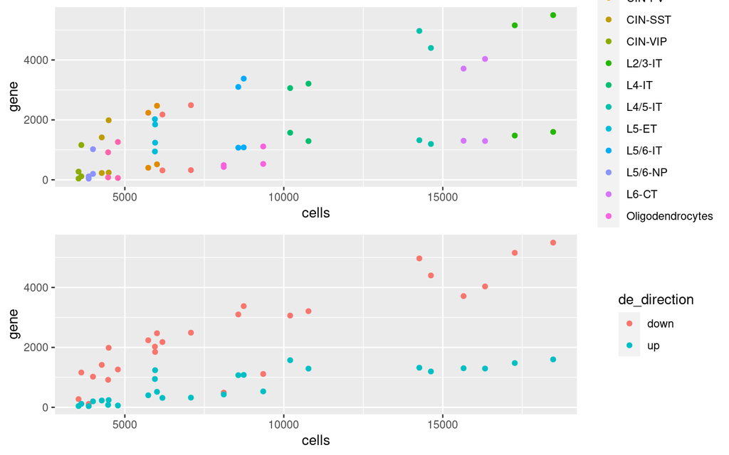

```r
p1 = df %>%
  ggplot(aes(x = cells, y = gene, color = name)) +
  geom_point()
p2 = df %>%
  ggplot(aes(x = cells, y = gene, color = de_direction)) +
  geom_point()

cowplot::plot_grid(p1, p2, ncol=1, align = "v")
```

We definitely need to consider DE Direction as a covariate

# Linear Model

$\mu = X\beta$ where $\mu$ is the number of genes designated differential

```r
m1 = lm(gene ~ cells + de_direction, data = df)
summary(m1)
```

```
##
## Call:
## lm(formula = gene ~ cells + de_direction, data = df)
##
## Residuals:
##     Min      1Q  Median      3Q     Max
## -1868.3  -377.2   164.8   336.7  1425.5
##
## Coefficients:
##                  Estimate Std. Error t value Pr(>|t|)
## (Intercept)     7.944e+02  2.289e+02   3.470  0.00109 **
## cells           1.928e-01  2.126e-02   9.069 4.66e-12 ***
## de_directionup -1.716e+03  1.968e+02  -8.722 1.54e-11 ***
## ---
## Signif. codes:  0 '***' 0.001 '**' 0.01 '*' 0.05 '.' 0.1 ' ' 1
##
## Residual standard error: 709.4 on 49 degrees of freedom
## Multiple R-squared:  0.7636, Adjusted R-squared:  0.754
## F-statistic: 79.16 on 2 and 49 DF,  p-value: 4.49e-16
```

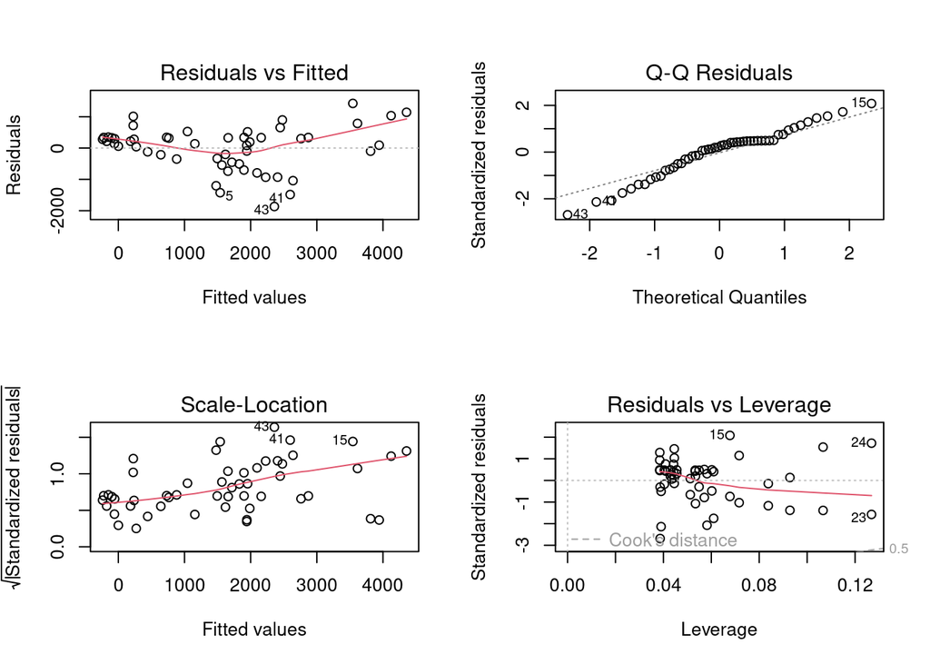

```r
par(mfrow = c(2,2))
plot(m1)
```

# Logistic Model

There is an upper and lower limit to the response variable. It can take on an integer value between zero and the number of genes (24181). It would make sense to model this with logistic regression

$\text{logit} (\mu) = X\beta$ where $\mu$ is the fraction of genes designated differential

```r
m2 = glm(gene_fraction ~ cells + de_direction, data = df, family = binomial())
summary(m2)
```

```
##
## Call:
## glm(formula = gene_fraction ~ cells + de_direction, family = binomial(),
##     data = df)
##
## Coefficients:
##                  Estimate Std. Error z value Pr(>|z|)
## (Intercept)    -3.3234219  1.3805386  -2.407   0.0161 *
## cells           0.0001183  0.0001131   1.046   0.2956
## de_directionup -1.3168755  1.3331461  -0.988   0.3233
## ---
## Signif. codes:  0 '***' 0.001 '**' 0.01 '*' 0.05 '.' 0.1 ' ' 1
##
## (Dispersion parameter for binomial family taken to be 1)
##
##     Null deviance: 2.8112  on 51  degrees of freedom
## Residual deviance: 0.6093  on 49  degrees of freedom
## AIC: 13.243
##
## Number of Fisher Scoring iterations: 6
```

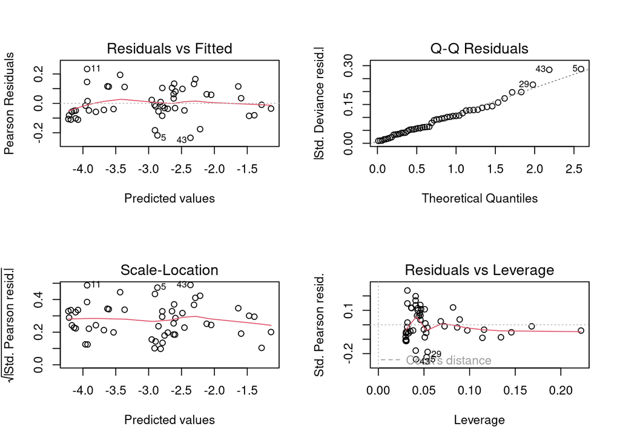

```r
par(mfrow = c(2,2))
plot(m2)
```

This model tells us the number of cells is NOT statistically significant for the number of DE genes. This is unfortunate because even tho the other 2 models are both generally interpretable, this should theoretically be the most applicable model.

# Poisson Model

Since the fraction of genes designated DE comes nowhere close to the upper limit, and since this is integer data (not continuous), Poisson regression also is applicable.

$\log (\mu) = X\beta$ where $\mu$ is the number of genes designated differential

```r
m3 = glm(gene ~ cells + de_direction, data = df, family = poisson())
summary(m3)
```

```
##
## Call:
## glm(formula = gene ~ cells + de_direction, family = poisson(),
##     data = df)
##
## Coefficients:
##                  Estimate Std. Error z value Pr(>|z|)
## (Intercept)     6.763e+00  8.552e-03   790.8   <2e-16 ***
## cells           1.058e-04  6.791e-07   155.9   <2e-16 ***
## de_directionup -1.212e+00  8.285e-03  -146.3   <2e-16 ***
## ---
## Signif. codes:  0 '***' 0.001 '**' 0.01 '*' 0.05 '.' 0.1 ' ' 1
##
## (Dispersion parameter for poisson family taken to be 1)
##
##     Null deviance: 63241  on 51  degrees of freedom
## Residual deviance: 14244  on 49  degrees of freedom
## AIC: 14699
##
## Number of Fisher Scoring iterations: 5
```

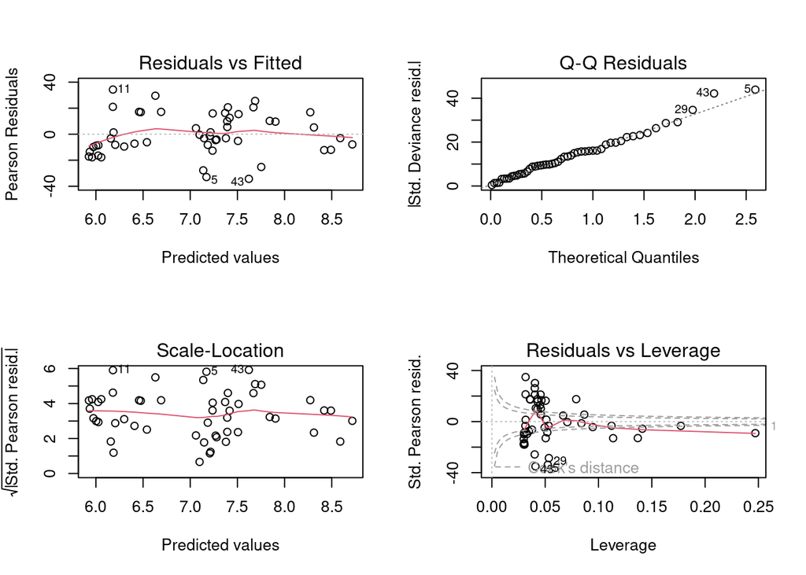

```r
par(mfrow = c(2,2))
plot(m3)
```

Residual diagnostics actually looks the best for the Poisson model, so we will adopt it. The number of cells is a significant factor for the number of DE genes. This supports our decision to normalize treatment combinations by cell count.